# R Notebook-modelling

```r
library(lme4)      # For mixed-effects models
library(lmerTest)  # For p-values with lmer()
library(tidyverse) # For data manipulation
```

# I must load my data first

```r
data <- read_delim("~/Documents/master_internship/outputs_final_data/final_df.csv", delim = ";")
data_session1 <- subset(data, session == "ses-mri01")
colnames(data)
```

```
 [1] "subject"               "session"               "stimuli_type"
 [4] "trial"                 "probability_condition" "switch"
 [7] "time_since_switch"     "volatility"            "response"
[10] "accuracy "   "RT_s"                  "trial_duration"
[13] "reward_amount"         "reward_change"         "reward_display"
[16] "congruency_response"   "task_congruency"       "switch_group"
[19] "block_size"
```

```r
head(data)
```

| subject | session | stimuli_type | trial | probability_condition | switch | time_since_switch | volatility | response | accuracy | RT_s | trial_duration | reward_amount | reward_change | reward_display | congruency_response | task_congruency | switch_group | block_size |
| --- | --- | --- | --- | --- | --- | --- | --- | --- | --- | --- | --- | --- | --- | --- | --- | --- | --- | --- |
| sub-005 | ses-mri01 | Angry | 10 | 80 | 0 | 0 | volatile | Avoid | 1 | 0.840 | 3.281859 | 0.0 | NA | unknown | congruent | incongruent | 0 | 32 |
| sub-005 | ses-mri01 | Angry | 11 | 80 | 0 | 1 | volatile | Avoid | 1 | 0.735 | 3.245877 | 0.1 | 0.1 | +10 cents | congruent | incongruent | 0 | 32 |
| sub-005 | ses-mri01 | Angry | 13 | 80 | 0 | 2 | volatile | Avoid | 1 | 0.751 | 4.130435 | 0.3 | 0.2 | unknown | congruent | incongruent | 0 | 32 |
| sub-005 | ses-mri01 | Angry | 14 | 80 | 0 | 3 | volatile | Avoid | 1 | 0.746 | 3.404798 | 0.4 | 0.1 | +10 cents | congruent | incongruent | 0 | 32 |
| sub-005 | ses-mri01 | Angry | 16 | 80 | 0 | 4 | volatile | Avoid | 1 | 0.652 | 4.814093 | 0.4 | 0.0 | unknown | congruent | incongruent | 0 | 32 |
| sub-005 | ses-mri01 | Angry | 18 | 80 | 0 | 5 | volatile | Avoid | 1 | 0.896 | 3.689655 | 0.4 | 0.0 | unknown | congruent | incongruent | 0 | 32 |

#I’m building up Congruency + RT here

```r
data$congruency_response <- factor(data$congruency_response)
data$volatility <- factor(data$volatility)
data$session <- factor(data$session)
```

#This is for all sessions

```r
model <- lmer(RT_s ~ congruency_response * time_since_switch * volatility * session +
              (1 + congruency_response | subject),
              data = data)
```

#But I am only interested in session 1 here

```r
model_session1 <- lmer(RT_s ~ congruency_response * time_since_switch * volatility +
                       (1 | subject),
                       data = data_session1)
```

```r
summary(model_session1)
```

```
Linear mixed model fit by REML. t-tests use Satterthwaite's method ['lmerModLmerTest']
Formula: RT_s ~ congruency_response * time_since_switch * volatility +      (1 | subject)
   Data: data_session1

REML criterion at convergence: -4064.9

Scaled residuals:
    Min      1Q  Median      3Q     Max
-4.4537 -0.6172 -0.0909  0.5359  4.5997

Random effects:
 Groups   Name        Variance Std.Dev.
 subject  (Intercept) 0.01101  0.1049
 Residual             0.02894  0.1701
Number of obs: 5940, groups:  subject, 9

Fixed effects:
                                                                      Estimate Std. Error
(Intercept)                                                          6.616e-01  3.591e-02
congruency_responseincongruent                                       1.283e-02  1.186e-02
time_since_switch                                                   -1.152e-03  4.685e-04
volatilityvolatile                                                  -1.934e-02  1.117e-02
congruency_responseincongruent:time_since_switch                     1.250e-03  6.934e-04
congruency_responseincongruent:volatilityvolatile                    3.074e-02  1.638e-02
time_since_switch:volatilityvolatile                                -9.994e-04  1.747e-03
congruency_responseincongruent:time_since_switch:volatilityvolatile -3.727e-03  2.558e-03
                                                                            df t value
(Intercept)                                                          8.822e+00  18.421
congruency_responseincongruent                                       5.924e+03   1.082
time_since_switch                                                    5.924e+03  -2.460
volatilityvolatile                                                   5.924e+03  -1.731
congruency_responseincongruent:time_since_switch                     5.924e+03   1.803
congruency_responseincongruent:volatilityvolatile                    5.924e+03   1.876
time_since_switch:volatilityvolatile                                 5.924e+03  -0.572
congruency_responseincongruent:time_since_switch:volatilityvolatile  5.924e+03  -1.457
                                                                    Pr(>|t|)
(Intercept)                                                          2.4e-08 ***
congruency_responseincongruent                                        0.2795
time_since_switch                                                     0.0139 *
volatilityvolatile                                                    0.0835 .
congruency_responseincongruent:time_since_switch                      0.0714 .
congruency_responseincongruent:volatilityvolatile                     0.0607 .
time_since_switch:volatilityvolatile                                  0.5673
congruency_responseincongruent:time_since_switch:volatilityvolatile   0.1453
---
Signif. codes:  0 ‘***’ 0.001 ‘**’ 0.01 ‘*’ 0.05 ‘.’ 0.1 ‘ ’ 1

Correlation of Fixed Effects:
            (Intr) cngrn_ tm_sn_ vltlty cn_:__ cngr_: tm_s_:
cngrncy_rsp -0.156
tm_snc_swtc -0.195  0.589
voltltyvltl -0.166  0.501  0.625
cngrncy_:__  0.131 -0.859 -0.676 -0.423
cngrncy_rs:  0.113 -0.723 -0.427 -0.682  0.622
tm_snc_swt:  0.052 -0.158 -0.268 -0.707  0.181  0.482
cngrnc_:__: -0.036  0.232  0.182  0.483 -0.270 -0.713 -0.683
```

#Now let’s see some plots

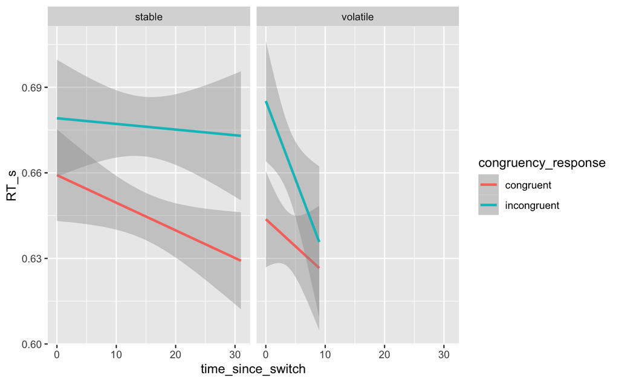

```r
ggplot(data_session1, aes(x = time_since_switch, y = RT_s, color = congruency_response)) +
  geom_smooth(method = "lm") +
  facet_wrap(~ volatility)
```

```r
NA
NA
```

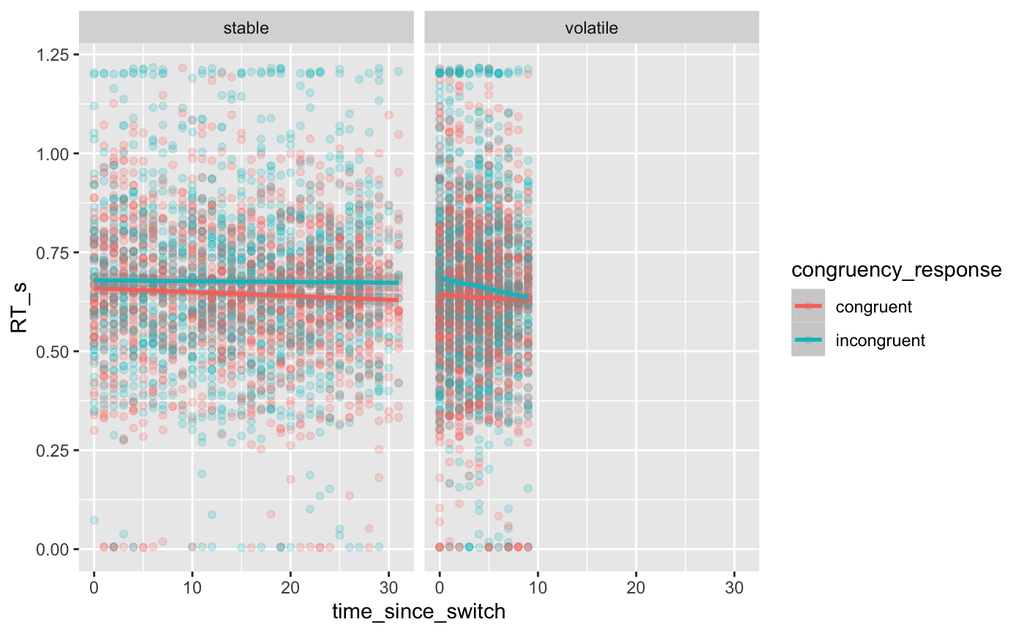

```r
ggplot(data_session1, aes(x = time_since_switch, y = RT_s, color = congruency_response)) +
  geom_point(alpha = 0.2) +
  geom_smooth(method = "lm") +
  facet_wrap(~ volatility)
```

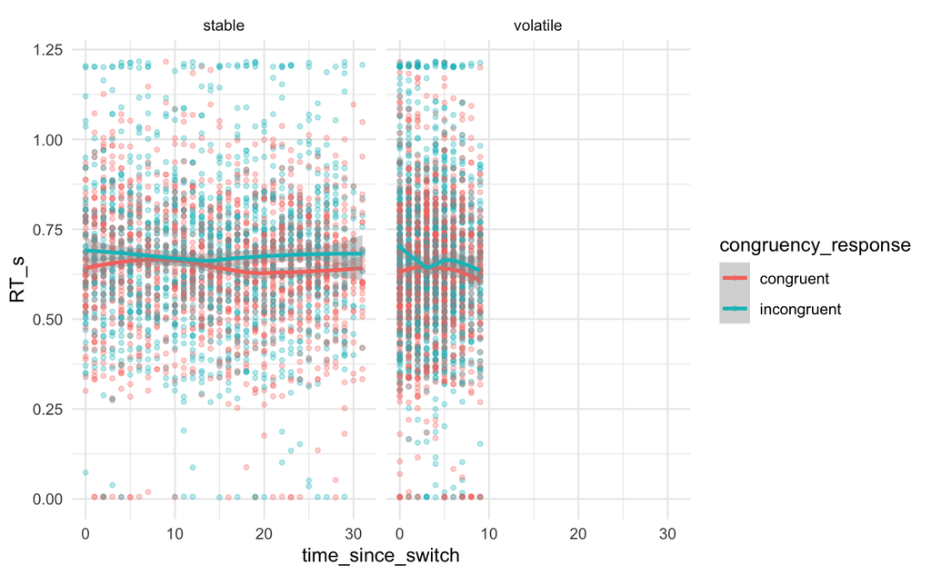

```r
ggplot(data_session1, aes(x = time_since_switch, y = RT_s, color = congruency_response)) +
  geom_point(alpha = 0.3, size = 1) +
  geom_smooth(method = "loess", se = TRUE) +
  facet_wrap(~ volatility) +
  theme_minimal()
```

#here following the SOP recommendations I want to find out whether my model is singular

```r
lme4::isSingular(model_session1, tol = 1e-4)
```

```
[1] FALSE
```

```r
lme4::isSingular(model_session1, tol = 1e-4)
```

```
[1] FALSE
```

```r
lme4::isSingular(model_session1, tol = 1e-4)
```

```
[1] FALSE
```

#Conservative estimation — just random intercepts to avoid overfitting, especially when you have singularity issues.

```r
model_summary <- lmer(
  RT_s ~ congruency_response * time_since_switch * volatility +
         (1 | subject),
  data = data_session1
)
```

```r
summary(model_session1)$varcor
```

```
 Groups   Name        Std.Dev.
 subject  (Intercept) 0.10493
 Residual             0.17012
```

# This means that the average subject-level variation in baseline RT is about 0.105 seconds (since your DV is RT_s, i.e. in seconds). That’s substantial, meaning there is meaningful variation across subjects in their average RTs.

# Residual: This reflects the remaining within-subject variability, i.e. how much RT varies from trial to trial within subjects. It’s naturally larger, as trial-by-trial noise is usually high.

#I do this to try a more maximal model and then reduce

```r
model_max <- lmer(RT_s ~ congruency_response * time_since_switch * volatility +
                  (1 + congruency_response | subject),
                  data = data_session1,
                  control = lmerControl(optimizer = "bobyqa", calc.derivs = FALSE))
```

```r
rePCA(model_max)
```

```
$subject
Standard deviations (1, .., p=2):
[1] 0.5786067 0.0000000

Rotation (n x k) = (2 x 2):
           [,1]       [,2]
[1,] -0.9793895 -0.2019808
[2,] -0.2019808  0.9793895

attr(,"class")
[1] "prcomplist"
```

```r
model_full <- lmer(RT_s ~ congruency_response * time_since_switch * volatility +
                   (1 + congruency_response | subject), data = data_session1,
                   control = lmerControl(optimizer = "bobyqa", calc.derivs = FALSE))
```

```r
model_simple <- lmer(RT_s ~ congruency_response * time_since_switch * volatility +
                     (1 | subject), data = data_session1)
```

#see which model is better

```r
anova(model_simple, model_full)
```

[output not shown]

#fitted a linear mixed-effects model predicting response times (RT_s) from a fully crossed interaction between congruency_response, time_since_switch, and volatility, with a random intercept for subject (model_simple).

#compared this to a model with both a random intercept and a random slope for congruency_response by subject (model_full), as recommended by Barr et al. (2013) to minimize inflated Type I error rates.

#Now I move forward with Congruency & Objective performance

```r
model_s1 <- glmer(accuracy  ~ congruency_response * time_since_switch +
                    (1 + congruency_response + time_since_switch | subject),
                  data = data_session1,
                  family = binomial)
```

```r
model_uncorrelated <- glmer(accuracy  ~ congruency_response * time_since_switch +
                              (1 + congruency_response + time_since_switch || subject),
                            data = data_session1,
                            family = binomial)
```

```r
rePCA(model_s1)
```

```
$subject
Standard deviations (1, .., p=3):
[1] 3.374390e-01 7.156391e-02 1.599399e-05

Rotation (n x k) = (3 x 3):
           [,1]       [,2]        [,3]
[1,] -0.9725650 -0.2218288 -0.07006673
[2,]  0.2281085 -0.8502685 -0.47435212
[3,]  0.0456494 -0.4773211  0.87754243

attr(,"class")
[1] "prcomplist"
```

```r
model_conservative <- lmer(
  RT_s ~ congruency_response * time_since_switch * volatility + (1 | subject),
  data = data_session1
)
```

```r
summary(model_conservative)
```

```
Linear mixed model fit by REML. t-tests use Satterthwaite's method ['lmerModLmerTest']
Formula: RT_s ~ congruency_response * time_since_switch * volatility +      (1 | subject)
   Data: data_session1

REML criterion at convergence: -4064.9

Scaled residuals:
    Min      1Q  Median      3Q     Max
-4.4537 -0.6172 -0.0909  0.5359  4.5997

Random effects:
 Groups   Name        Variance Std.Dev.
 subject  (Intercept) 0.01101  0.1049
 Residual             0.02894  0.1701
Number of obs: 5940, groups:  subject, 9

Fixed effects:
                                                                      Estimate Std. Error
(Intercept)                                                          6.616e-01  3.591e-02
congruency_responseincongruent                                       1.283e-02  1.186e-02
time_since_switch                                                   -1.152e-03  4.685e-04
volatilityvolatile                                                  -1.934e-02  1.117e-02
congruency_responseincongruent:time_since_switch                     1.250e-03  6.934e-04
congruency_responseincongruent:volatilityvolatile                    3.074e-02  1.638e-02
time_since_switch:volatilityvolatile                                -9.994e-04  1.747e-03
congruency_responseincongruent:time_since_switch:volatilityvolatile -3.727e-03  2.558e-03
                                                                            df t value
(Intercept)                                                          8.822e+00  18.421
congruency_responseincongruent                                       5.924e+03   1.082
time_since_switch                                                    5.924e+03  -2.460
volatilityvolatile                                                   5.924e+03  -1.731
congruency_responseincongruent:time_since_switch                     5.924e+03   1.803
congruency_responseincongruent:volatilityvolatile                    5.924e+03   1.876
time_since_switch:volatilityvolatile                                 5.924e+03  -0.572
congruency_responseincongruent:time_since_switch:volatilityvolatile  5.924e+03  -1.457
                                                                    Pr(>|t|)
(Intercept)                                                          2.4e-08 ***
congruency_responseincongruent                                        0.2795
time_since_switch                                                     0.0139 *
volatilityvolatile                                                    0.0835 .
congruency_responseincongruent:time_since_switch                      0.0714 .
congruency_responseincongruent:volatilityvolatile                     0.0607 .
time_since_switch:volatilityvolatile                                  0.5673
congruency_responseincongruent:time_since_switch:volatilityvolatile   0.1453
---
Signif. codes:  0 ‘***’ 0.001 ‘**’ 0.01 ‘*’ 0.05 ‘.’ 0.1 ‘ ’ 1

Correlation of Fixed Effects:
            (Intr) cngrn_ tm_sn_ vltlty cn_:__ cngr_: tm_s_:
cngrncy_rsp -0.156
tm_snc_swtc -0.195  0.589
voltltyvltl -0.166  0.501  0.625
cngrncy_:__  0.131 -0.859 -0.676 -0.423
cngrncy_rs:  0.113 -0.723 -0.427 -0.682  0.622
tm_snc_swt:  0.052 -0.158 -0.268 -0.707  0.181  0.482
cngrnc_:__: -0.036  0.232  0.182  0.483 -0.270 -0.713 -0.683
```

#to check residuals:

```r
plot(model_conservative)       # Residuals vs. fitted, scale-location, etc.
qqnorm(resid(model_conservative))
qqline(resid(model_conservative))
```

[output not shown]

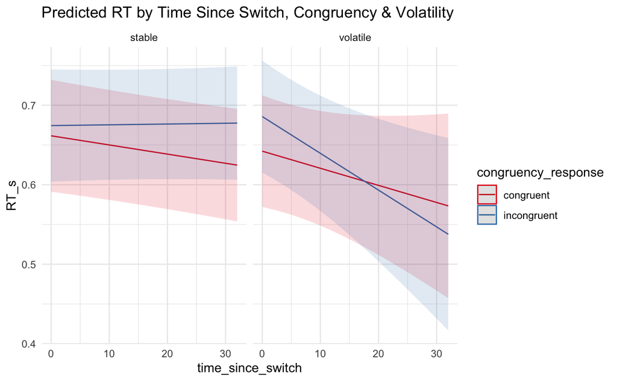

```r
plot(ggpredict(
  model_conservative,
  terms = c("time_since_switch", "congruency_response", "volatility")
)) +
  ggtitle("Predicted RT by Time Since Switch, Congruency & Volatility") +
  theme_minimal()
```